# Online Sales Dataset

## Online Shopping Patterns and Retail Performance Dataset

**https://www.kaggle.com/datasets/yusufdelikkaya/online-sales-dataset/data**

## Description:

- The dataset comprises anonymized data on online sales transactions, capturing various aspects of product purchases, customer details, and order characteristics.
- This dataset can be utilized for analyzing sales trends, customer purchase behavior, and order management in e-commerce or retail.
- It can aid in understanding the impact of discounts, payment methods, and shipment providers on sales performance and customer satisfaction.
- This dataset can be utilized for analyzing sales performance, customer purchasing patterns, and operational efficiency in order management.
- It can help in evaluating the effects of discounts and payment methods on sales, optimizing inventory by studying product demand, and improving customer satisfaction through better shipping and return handling.

# Features

- **InvoiceNo**: A unique identifier for each sales transaction (invoice).
- **StockCode**: The code representing the product stock-keeping unit (SKU).
- **Description**: A brief description of the product.
- **Quantity**: The number of units of the product sold in the transaction.
- **InvoiceDate**: The date and time when the sale was recorded.
- **UnitPrice**: The price per unit of the product in the transaction currency.
- **CustomerID**: A unique identifier for each customer.
- **Country**: The customer's country.
- **Discount**: The discount applied to the transaction, if any.
- **PaymentMethod**: The method of payment used for the transaction (e.g., PayPal, Bank Transfer).
- **ShippingCost**: The cost of shipping for the transaction.
- **Category**: The category to which the product belongs (e.g., Electronics, Apparel).
- **SalesChannel**: The channel through which the sale was made (e.g., Online, In-store).
- **ReturnStatus**: Indicates whether the item was returned or not.
- **ShipmentProvider**: The provider responsible for delivering the order (e.g., UPS, FedEx).
- **WarehouseLocation**: The warehouse location from which the order was fulfilled.
- **OrderPriority**: The priority level of the order (e.g., Hgh, Medium, Low).

```python
#!pip install kaggle
```

```python
import pandas as pd
import numpy as np
import matplotlib.pyplot as plt
import seaborn as sns
```

```python
file_path = r'C:\Users\myloc\Downloads\online_sales_dataset.csv'
df = pd.read_csv(file_path)
```

## General Data Overview

```python
df.head(10)
```

|  | InvoiceNo | StockCode | Description | Quantity | InvoiceDate | UnitPrice | CustomerID | Country | Discount | PaymentMethod | ShippingCost | Category | SalesChannel | ReturnStatus | ShipmentProvider | WarehouseLocation | OrderPriority |
| --- | --- | --- | --- | --- | --- | --- | --- | --- | --- | --- | --- | --- | --- | --- | --- | --- | --- |
| 0 | 221958 | SKU_1964 | White Mug | 38 | 2020-01-01 00:00 | 1.71 | 37039.0 | Australia | 0.470000 | Bank Transfer | 10.79 | Apparel | In-store | Not Returned | UPS | London | Medium |
| 1 | 771155 | SKU_1241 | White Mug | 18 | 2020-01-01 01:00 | 41.25 | 19144.0 | Spain | 0.190000 | paypall | 9.51 | Electronics | Online | Not Returned | UPS | Rome | Medium |
| 2 | 231932 | SKU_1501 | Headphones | 49 | 2020-01-01 02:00 | 29.11 | 50472.0 | Germany | 0.350000 | Bank Transfer | 23.03 | Electronics | Online | Returned | UPS | Berlin | High |
| 3 | 465838 | SKU_1760 | Desk Lamp | 14 | 2020-01-01 03:00 | 76.68 | 96586.0 | Netherlands | 0.140000 | paypall | 11.08 | Accessories | Online | Not Returned | Royal Mail | Rome | Low |
| 4 | 359178 | SKU_1386 | USB Cable | -30 | 2020-01-01 04:00 | -68.11 | NaN | United Kingdom | 1.501433 | Bank Transfer | NaN | Electronics | In-store | Not Returned | FedEx | NaN | Medium |
| 5 | 744167 | SKU_1006 | Office Chair | 47 | 2020-01-01 05:00 | 70.16 | 53887.0 | Sweden | 0.480000 | Credit Card | 13.98 | Electronics | Online | Not Returned | DHL | London | Medium |
| 6 | 210268 | SKU_1087 | USB Cable | 25 | 2020-01-01 06:00 | 85.74 | 46567.0 | Belgium | 0.150000 | Bank Transfer | 12.92 | Stationery | Online | Not Returned | FedEx | Amsterdam | High |
| 7 | 832180 | SKU_1597 | Notebook | 8 | 2020-01-01 07:00 | 95.65 | 75098.0 | Norway | 0.040000 | Bank Transfer | 6.48 | Electronics | In-store | Not Returned | Royal Mail | Amsterdam | Low |
| 8 | 154886 | SKU_1907 | Wireless Mouse | 19 | 2020-01-01 08:00 | 98.19 | 87950.0 | Belgium | 0.050000 | paypall | 12.56 | Apparel | Online | Not Returned | UPS | Berlin | High |
| 9 | 237337 | SKU_1866 | Headphones | 40 | 2020-01-01 09:00 | 98.17 | 39718.0 | Italy | 0.160000 | Bank Transfer | 7.71 | Apparel | Online | Not Returned | Royal Mail | London | Low |

```python
df.tail()
```

|  | InvoiceNo | StockCode | Description | Quantity | InvoiceDate | UnitPrice | CustomerID | Country | Discount | PaymentMethod | ShippingCost | Category | SalesChannel | ReturnStatus | ShipmentProvider | WarehouseLocation | OrderPriority |
| --- | --- | --- | --- | --- | --- | --- | --- | --- | --- | --- | --- | --- | --- | --- | --- | --- | --- |
| 49777 | 354083 | SKU_1562 | Blue Pen | 25 | 2025-09-05 01:00 | 70.92 | 51445.0 | Spain | 0.20 | Credit Card | 8.96 | Electronics | Online | Returned | UPS | Berlin | Medium |
| 49778 | 296698 | SKU_1930 | USB Cable | 7 | 2025-09-05 02:00 | 51.74 | 28879.0 | United States | 0.23 | Bank Transfer | 23.55 | Electronics | Online | Not Returned | FedEx | Amsterdam | Low |
| 49779 | 177622 | SKU_1766 | Office Chair | 43 | 2025-09-05 03:00 | 85.25 | 21825.0 | Portugal | 0.20 | Bank Transfer | 16.26 | Furniture | In-store | Not Returned | FedEx | London | High |
| 49780 | 701213 | SKU_1602 | Notebook | 48 | 2025-09-05 04:00 | 39.64 | 43199.0 | United Kingdom | 0.31 | paypall | 28.56 | Apparel | Online | Not Returned | Royal Mail | London | Medium |
| 49781 | 772215 | SKU_1832 | White Mug | 30 | 2025-09-05 05:00 | 38.27 | 53328.0 | France | 0.10 | Credit Card | 9.13 | Stationery | Online | Not Returned | UPS | Rome | Low |

```python
df.shape
```

```
(49782, 17)
```

```python
df.info()
```

```
<class 'pandas.core.frame.DataFrame'>
RangeIndex: 49782 entries, 0 to 49781
Data columns (total 17 columns):
 #   Column             Non-Null Count  Dtype
---  ------             --------------  -----
 0   InvoiceNo          49782 non-null  int64
 1   StockCode          49782 non-null  object
 2   Description        49782 non-null  object
 3   Quantity           49782 non-null  int64
 4   InvoiceDate        49782 non-null  object
 5   UnitPrice          49782 non-null  float64
 6   CustomerID         44804 non-null  float64
 7   Country            49782 non-null  object
 8   Discount           49782 non-null  float64
 9   PaymentMethod      49782 non-null  object
 10  ShippingCost       47293 non-null  float64
 11  Category           49782 non-null  object
 12  SalesChannel       49782 non-null  object
 13  ReturnStatus       49782 non-null  object
 14  ShipmentProvider   49782 non-null  object
 15  WarehouseLocation  46297 non-null  object
 16  OrderPriority      49782 non-null  object
dtypes: float64(4), int64(2), object(11)
memory usage: 6.5+ MB
```

## Descriptive Statistics

**checking the sum of missing values and their percentage**

```python
missing_data = df.isnull().sum().sort_values(ascending=False)
missing_percentage = (missing_data / len(df)) * 100
print(pd.DataFrame({'Missing Values': missing_data, 'Percentage': missing_percentage}))
```

```
                   Missing Values  Percentage
CustomerID                   4978    9.999598
WarehouseLocation            3485    7.000522
ShippingCost                 2489    4.999799
InvoiceNo                       0    0.000000
PaymentMethod                   0    0.000000
ShipmentProvider                0    0.000000
ReturnStatus                    0    0.000000
SalesChannel                    0    0.000000
Category                        0    0.000000
Discount                        0    0.000000
StockCode                       0    0.000000
Country                         0    0.000000
UnitPrice                       0    0.000000
InvoiceDate                     0    0.000000
Quantity                        0    0.000000
Description                     0    0.000000
OrderPriority                   0    0.000000
```

```python
# lets drop the Invoice No for since it doesn't affect our analysis
df = df.drop(columns=['InvoiceNo'])
```

```python
df.describe()
```

|  | Quantity | UnitPrice | CustomerID | Discount | ShippingCost |
| --- | --- | --- | --- | --- | --- |
| count | 49782.000000 | 49782.000000 | 44804.000000 | 49782.000000 | 47293.000000 |
| mean | 22.372343 | 47.537862 | 55032.871775 | 0.275748 | 17.494529 |
| std | 17.917774 | 33.479510 | 25913.660157 | 0.230077 | 7.220557 |
| min | -50.000000 | -99.980000 | 10001.000000 | 0.000000 | 5.000000 |
| 25% | 11.000000 | 23.592500 | 32750.750000 | 0.130000 | 11.220000 |
| 50% | 23.000000 | 48.920000 | 55165.000000 | 0.260000 | 17.500000 |
| 75% | 37.000000 | 74.610000 | 77306.250000 | 0.380000 | 23.720000 |
| max | 49.000000 | 100.000000 | 99998.000000 | 1.999764 | 30.000000 |

**Unique values in categorical columns**

```python
categorical_cols = ['StockCode', 'Description', 'Country', 'PaymentMethod', 'Category', 'SalesChannel', 'ReturnStatus', 'ShipmentProvider', 'WarehouseLocation', 'OrderPriority']
for col in categorical_cols:
    print(f"Unique values in {col}: {df[col].nunique()}")
```

```
Unique values in StockCode: 1000
Unique values in Description: 11
Unique values in Country: 12
Unique values in PaymentMethod: 3
Unique values in Category: 5
Unique values in SalesChannel: 2
Unique values in ReturnStatus: 2
Unique values in ShipmentProvider: 4
Unique values in WarehouseLocation: 5
Unique values in OrderPriority: 3
```

## Data Cleaning

**Checking for duplicate values**

```python
df.duplicated().sum()
```

```
0
```

**Imputating Missing Values**

```python
# Calculate the mode of the CustomerID column
customer_id_mode = df['CustomerID'].mode()[0]

# Fill missing values in CustomerID with the mode
df['CustomerID'].fillna(customer_id_mode, inplace=True)
```

```python
# Calculate the mode of the WarehouseLocation column
Warehouse_Location_mode = df['WarehouseLocation'].mode()[0]

# Fill missing values in CustomerID with the mode
df['WarehouseLocation'].fillna(Warehouse_Location_mode, inplace=True)
```

```python
# Calculate the mode of the ShippingCost column
Shipping_Cost_mode = df['ShippingCost'].mode()[0]

# Fill missing values in CustomerID with the mode
df['ShippingCost'].fillna(Shipping_Cost_mode, inplace=True)
```

```python
#Convert CustomerID from float to integer by removing decimal points
df['CustomerID'] = df['CustomerID'].astype(int)
```

**Removing the (-) from Quantity, Unit Price, ShippingCost**

- The .abs() method converts any negative values to positive, effectively removing the negative sign.

```python
# Remove negative signs by converting values to absolute
df['Quantity'] = df['Quantity'].abs()
df['UnitPrice'] = df['UnitPrice'].abs()
df['ShippingCost'] = df['ShippingCost'].abs()
```

**Rounding Discount to two decimal places**

```python
df['Discount'] = round(df['Discount'], 2)
```

## Feature Engineering

```python
# Convert InvoiceDate to datetime and create new columns
df['InvoiceDate'] = pd.to_datetime(df['InvoiceDate'])
df['Year'] = df['InvoiceDate'].dt.year
df['Month'] = df['InvoiceDate'].dt.month
df['Day'] = df['InvoiceDate'].dt.day
df['Hour'] = df['InvoiceDate'].dt.hour
```

```python
df.head()
```

|  | StockCode | Description | Quantity | InvoiceDate | UnitPrice | CustomerID | Country | Discount | PaymentMethod | ShippingCost | Category | SalesChannel | ReturnStatus | ShipmentProvider | WarehouseLocation | OrderPriority | Year | Month | Day | Hour |
| --- | --- | --- | --- | --- | --- | --- | --- | --- | --- | --- | --- | --- | --- | --- | --- | --- | --- | --- | --- | --- |
| 0 | SKU_1964 | White Mug | 38 | 2020-01-01 00:00:00 | 1.71 | 37039 | Australia | 0.47 | Bank Transfer | 10.79 | Apparel | In-store | Not Returned | UPS | London | Medium | 2020 | 1 | 1 | 0 |
| 1 | SKU_1241 | White Mug | 18 | 2020-01-01 01:00:00 | 41.25 | 19144 | Spain | 0.19 | paypall | 9.51 | Electronics | Online | Not Returned | UPS | Rome | Medium | 2020 | 1 | 1 | 1 |
| 2 | SKU_1501 | Headphones | 49 | 2020-01-01 02:00:00 | 29.11 | 50472 | Germany | 0.35 | Bank Transfer | 23.03 | Electronics | Online | Returned | UPS | Berlin | High | 2020 | 1 | 1 | 2 |
| 3 | SKU_1760 | Desk Lamp | 14 | 2020-01-01 03:00:00 | 76.68 | 96586 | Netherlands | 0.14 | paypall | 11.08 | Accessories | Online | Not Returned | Royal Mail | Rome | Low | 2020 | 1 | 1 | 3 |
| 4 | SKU_1386 | USB Cable | 30 | 2020-01-01 04:00:00 | 68.11 | 53125 | United Kingdom | 1.50 | Bank Transfer | 5.34 | Electronics | In-store | Not Returned | FedEx | Amsterdam | Medium | 2020 | 1 | 1 | 4 |

# Visualization Analysis

## 1. Distribution of Numerical Columns

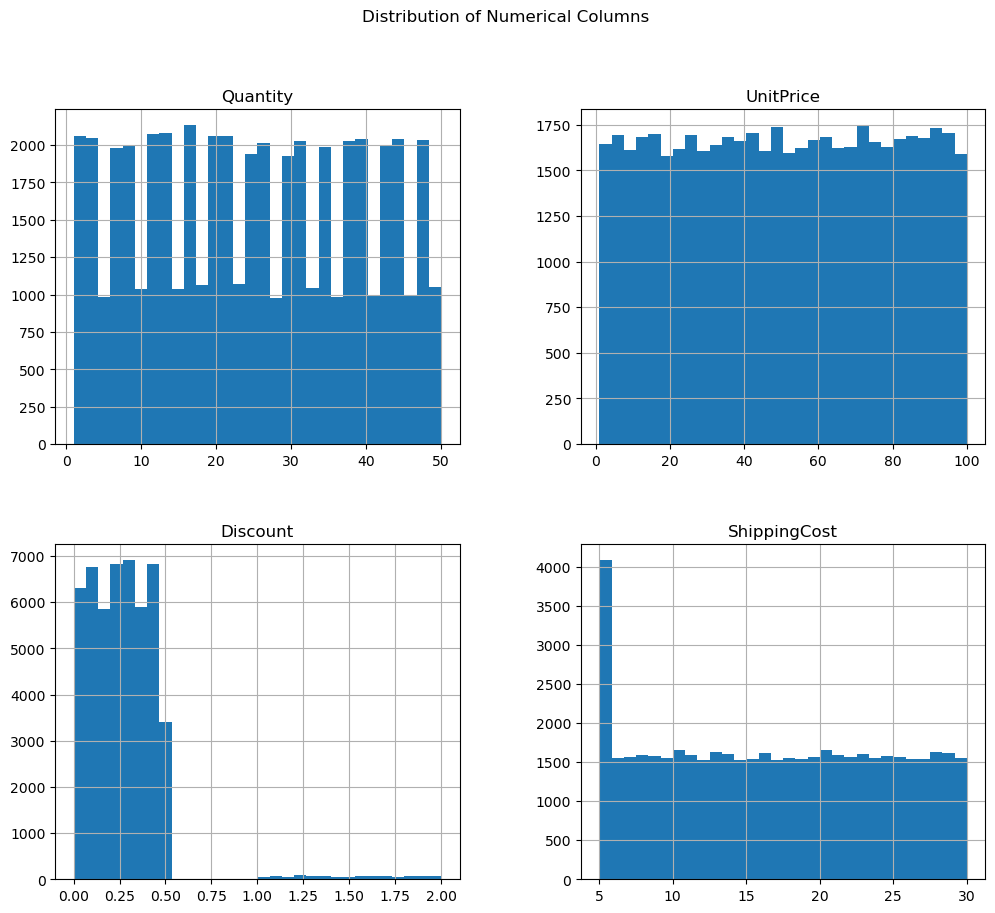

```python
numerical_cols = ['Quantity', 'UnitPrice', 'Discount', 'ShippingCost']
df[numerical_cols].hist(bins=30, figsize=(12, 10))
plt.suptitle("Distribution of Numerical Columns")
plt.show()
```

## 2. Categorical Data Visualization

**a) Sales Count by Country**

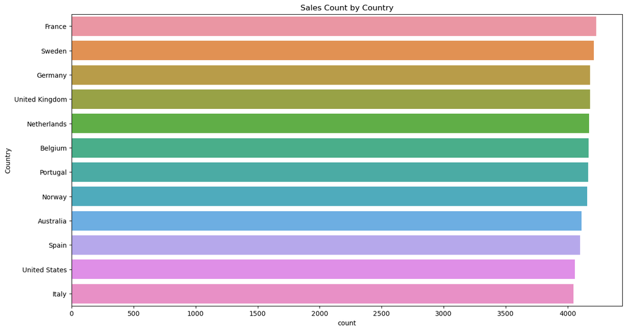

```python
plt.figure(figsize=(15, 8))
sns.countplot(data=df, y='Country', order=df['Country'].value_counts().index)
plt.title("Sales Count by Country")
plt.show()
```

**b. Product Category Distribution**

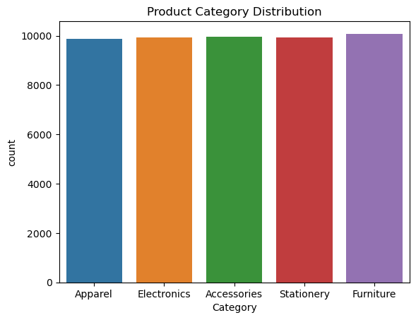

```python
# Category and SalesChannel distribution
sns.countplot(data=df, x='Category')
plt.title("Product Category Distribution")
plt.show()
```

**c. Sales Channel Distribution**

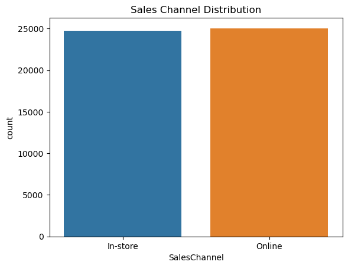

```python
sns.countplot(data=df, x='SalesChannel')
plt.title("Sales Channel Distribution")
plt.show()
```

**d. Return Status Distribution**

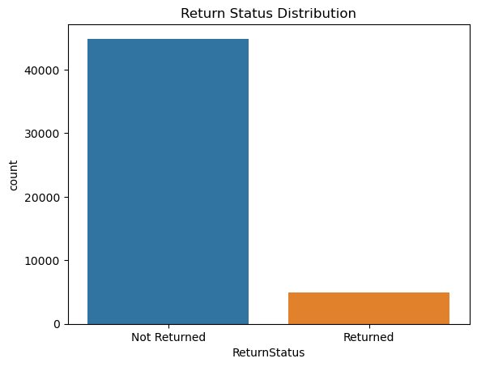

```python
sns.countplot(data=df, x='ReturnStatus')
plt.title("Return Status Distribution")
plt.show()
```

## 3. Bivariate Analysis

**a. Discount vs. Quantity scatter plot**

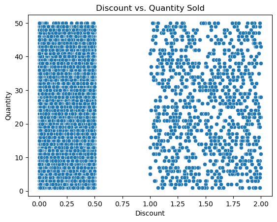

```python
sns.scatterplot(data=df, x='Discount', y='Quantity')
plt.title("Discount vs. Quantity Sold")
plt.show()
```

**b. ShippingCost by Country**

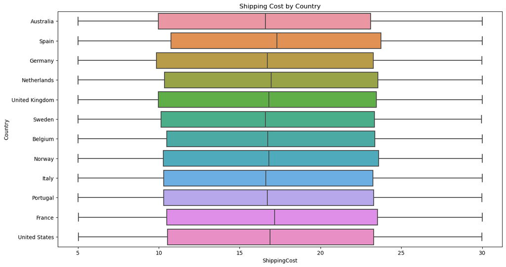

```python
plt.figure(figsize=(15, 8))
sns.boxplot(data=df, x='ShippingCost', y='Country')
plt.title("Shipping Cost by Country")
plt.show()
```

**c. UnitPrice by Category**

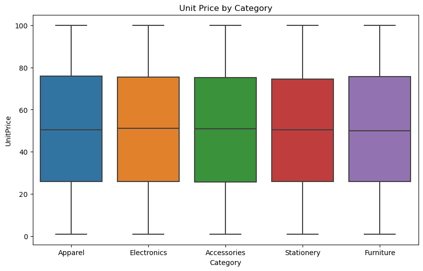

```python
plt.figure(figsize=(10, 6))
sns.boxplot(data=df, x='Category', y='UnitPrice')
plt.title("Unit Price by Category")
plt.show()
```

## 4.Order Priority Analysis

**a. Order Priority distribution**

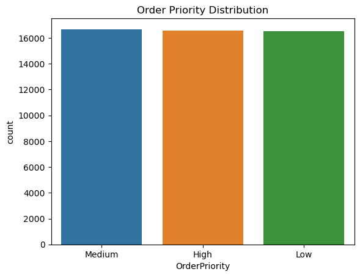

```python
sns.countplot(data=df, x='OrderPriority')
plt.title("Order Priority Distribution")
plt.show()
```

**b. Average Quantity by Order Priority**

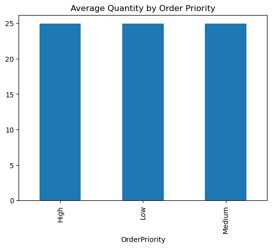

```python
df.groupby('OrderPriority')['Quantity'].mean().plot(kind='bar')
plt.title("Average Quantity by Order Priority")
plt.show()
```

## Correlation heatmap

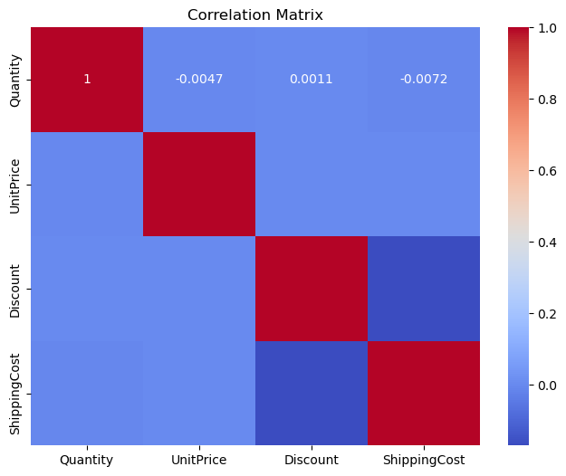

```python
plt.figure(figsize=(8, 6))
sns.heatmap(df[['Quantity', 'UnitPrice', 'Discount', 'ShippingCost']].corr(), annot=True, cmap='coolwarm')
plt.title("Correlation Matrix")
plt.show()
```